# UFO sightings and Nuclear Plants in the UK

Autogenerated data summary from dataMaid

2020-12-11 17:05:33

# Data report overview

The dataset examined has the following dimensions:

| Feature | Result |
| --- | --- |
| Number of observations | 1480 |
| Number of variables | 15 |

### Checks performed

The following variable checks were performed, depending on the data type of each variable:

|  | character | factor | labelled | haven labelled | numeric | integer | logical | Date |
| --- | --- | --- | --- | --- | --- | --- | --- | --- |
| Identify miscoded missing values | × | × | × | × | × | × |  | × |
| Identify prefixed and suffixed whitespace | × | × | × | × |  |  |  |  |
| Identify levels with < 6 obs. | × | × | × | × |  |  |  |  |
| Identify case issues | × | × | × | × |  |  |  |  |
| Identify misclassified numeric or integer variables | × | × | × | × |  |  |  |  |
| Identify outliers |  |  |  |  | × | × |  | × |

Please note that all numerical values in the following have been rounded to 2 decimals.

# Codebook summary table

| Label | Variable | Class | # unique values | Missing | Description |
| --- | --- | --- | --- | --- | --- |
|  | **datetime** | character | 1453 | 0.00 % |  |
|  | **date.posted** | character | 253 | 0.00 % |  |
|  | **duration** | character | 123 | 0.00 % |  |
|  | **shape** | character | 21 | 0.00 % |  |
|  | **comments** | character | 1479 | 0.00 % |  |
|  | **City** | character | 470 | 0.00 % |  |
|  | **Country** | character | 8 | 0.00 % |  |
|  | **Region** | character | 1 | 0.00 % |  |
|  | **latitude** | numeric | 279 | 0.00 % |  |
|  | **longitude** | numeric | 286 | 0.00 % |  |
|  | **Address** | character | 475 | 0.00 % |  |
|  | **plant_in_city** | character | 2 | 0.00 % |  |
|  | **plant_name** | character | 10 | 0.00 % |  |
|  | **plant_latitude** | character | 8 | 0.00 % |  |
|  | **plant_longitude** | character | 8 | 0.00 % |  |

# Variable list

## datetime

| Feature | Result |
| --- | --- |
| Variable type | character |
| Number of missing obs. | 0 (0 %) |
| Number of unique values | 1453 |
| Mode | “9/21/2012 23:00” |

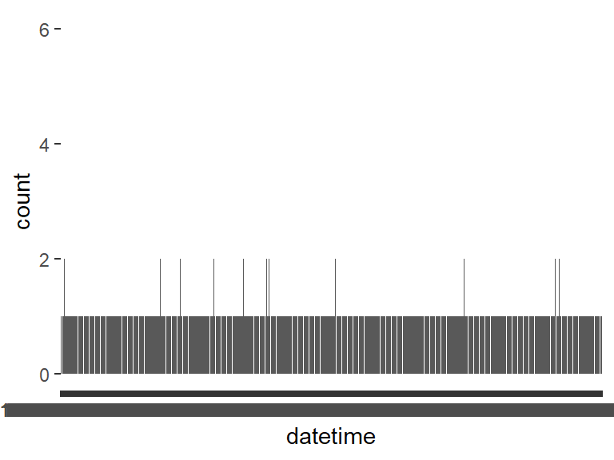

- Note that the following levels have at most five observations: "1/1/1978 0:00", "1/1/1982 17:00", "1/1/2002 13:00", "1/1/2002 22:00", "1/1/2003 0:05", "1/1/2003 0:20", "1/1/2004 12:00", "1/1/2005 3:30", "1/1/2007 19:45", "1/1/2008 0:10" (1442 additional values omitted).

## date.posted

| Feature | Result |
| --- | --- |
| Variable type | character |
| Number of missing obs. | 0 (0 %) |
| Number of unique values | 253 |
| Mode | “10/30/2006” |

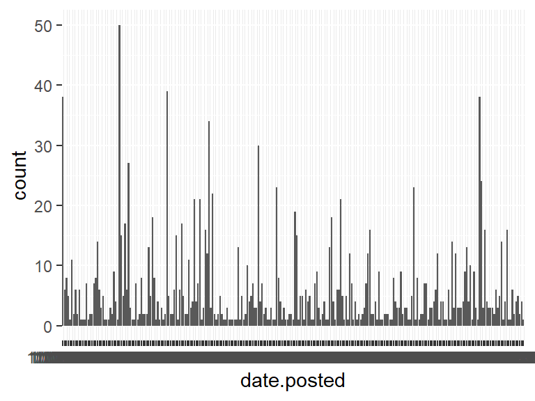

- Note that the following levels have at most five observations: "1/11/2005", "1/12/2012", "1/19/2005", "1/22/2000", "1/24/2014", "1/27/2005", "1/28/1999", "1/3/2001", "1/31/2004", "1/31/2011" (163 additional values omitted).

## duration

| Feature | Result |
| --- | --- |
| Variable type | character |
| Number of missing obs. | 0 (0 %) |
| Number of unique values | 123 |
| Mode | “5 min” |

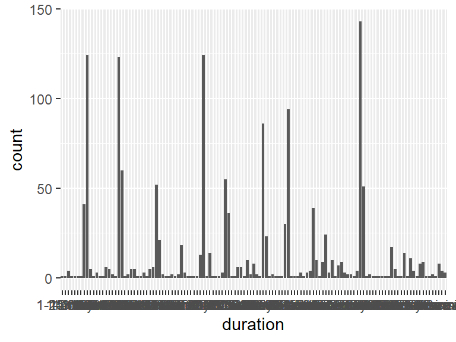

- Note that the following levels have at most five observations: "1-15 min", "1-2 hours", "1-2 min", "1-3 min", "1-4 min", "1-6 sec", "1 days", "1 sec", "1.26 min", "1.5 min" (76 additional values omitted).

## shape

| Feature | Result |
| --- | --- |
| Variable type | character |
| Number of missing obs. | 0 (0 %) |
| Number of unique values | 21 |
| Mode | “light” |

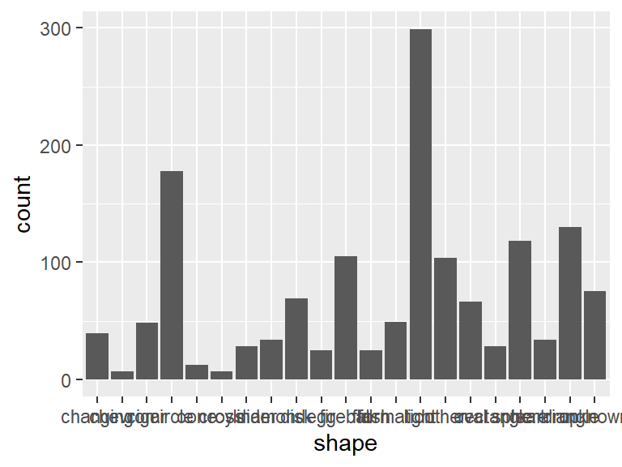

## comments

| Feature | Result |
| --- | --- |
| Variable type | character |
| Number of missing obs. | 0 (0 %) |
| Number of unique values | 1479 |
| Mode | “bright glowing object left tracer mark as it sped off” |

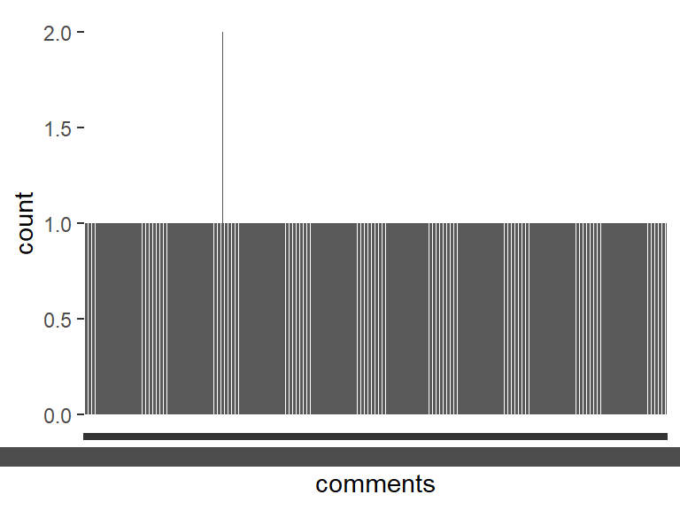

- The following values appear with prefixed or suffixed white space: " ((HOAX??)) This was a red light which was moving quite fast over Aberdeen&#44 Scotland.".
- Note that the following levels have at most five observations: " ((HOAX??)) This was a red light which was moving quite fast over Aberdeen&#44 Scotland.", "&#39Floating&#39 rectangular &#39sheet of paper&#39&#44&#44&#44", "“like someone had hung christmas deccy&#39s in the sky”", "((HOAX POSSIBLY)) It was winter of 2005 and a cold night.", "((HOAX)) A fleet of ships landed in my back garden and took off again.", "((HOAX)) RAF CHASES SINGLE RED LIGHT", "((HOAX/OBSCENE) ((deleted)) scary", "((HOAX? Date is flawed.)) Solid orange V shape flying past and over no lights just a solid radiating orange V", "((HOAX?? Student report)) Witnessed 30ft diameter meteor type thing accelerate into the sky then disappear after five seconds…", "((HOAX??) We saw a very quick cigar shape go past 8 times." (1469 additional values omitted).

## City

| Feature | Result |
| --- | --- |
| Variable type | character |
| Number of missing obs. | 0 (0 %) |
| Number of unique values | 470 |
| Mode | “london” |

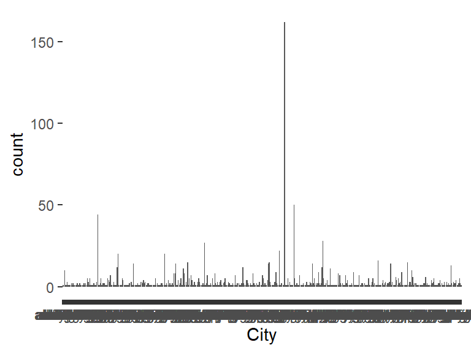

- Note that the following levels have at most five observations: "abercarn", "aberdare", "abersoch", "abingdon", "accrington", "ackworth", "addingham", "addlestone", "aldershot", "alfreton" (413 additional values omitted).

## Country

| Feature | Result |
| --- | --- |
| Variable type | character |
| Number of missing obs. | 0 (0 %) |
| Number of unique values | 8 |
| Mode | " England" |

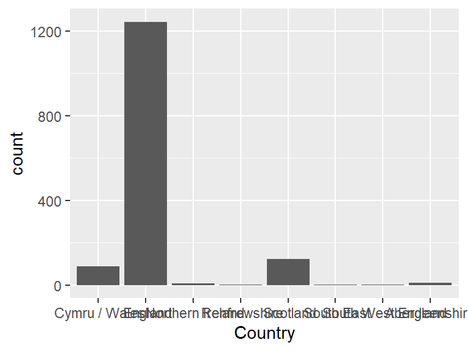

- The following values appear with prefixed or suffixed white space: " Cymru / Wales", " England", " Northern Ireland", " Renfrewshire", " Scotland", " South East", " South West England".
- Note that the following levels have at most five observations: " Renfrewshire", " South East", " South West England".

## Region

- The variable only takes one (non-missing) value: " United Kingdom". The variable contains 0 % missing observations.

## latitude

| Feature | Result |
| --- | --- |
| Variable type | numeric |
| Number of missing obs. | 0 (0 %) |
| Number of unique values | 279 |
| Median | 52.47 |
| 1st and 3rd quartiles | 51.51; 53.5 |
| Min. and max. | 50.11; 57.87 |

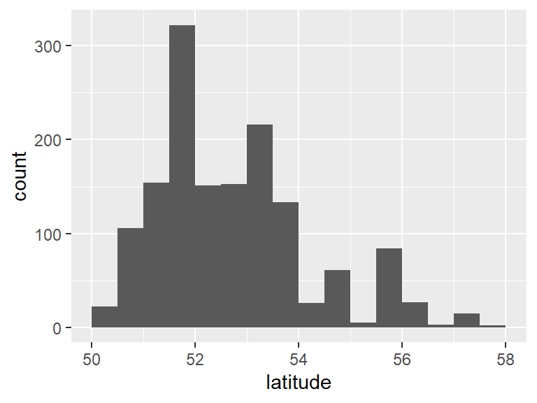

- Note that the following possible outlier values were detected: "57.47", "57.65", "57.87".

## longitude

| Feature | Result |
| --- | --- |
| Variable type | numeric |
| Number of missing obs. | 0 (0 %) |
| Number of unique values | 286 |
| Median | -1.55 |
| 1st and 3rd quartiles | -2.67; -0.4 |
| Min. and max. | -7.2; 1.75 |

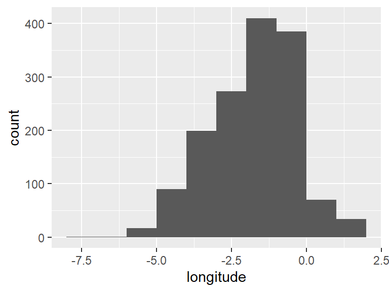

- Note that the following possible outlier values were detected: "-7.2".

## Address

| Feature | Result |
| --- | --- |
| Variable type | character |
| Number of missing obs. | 0 (0 %) |
| Number of unique values | 475 |
| Mode | “[‘107’, ’ Cheapside’, ’ Barbican’, ’ City of London’, ’ Greater London’, ’ England’, ’ EC2’, ’ United Kingdom’]” |

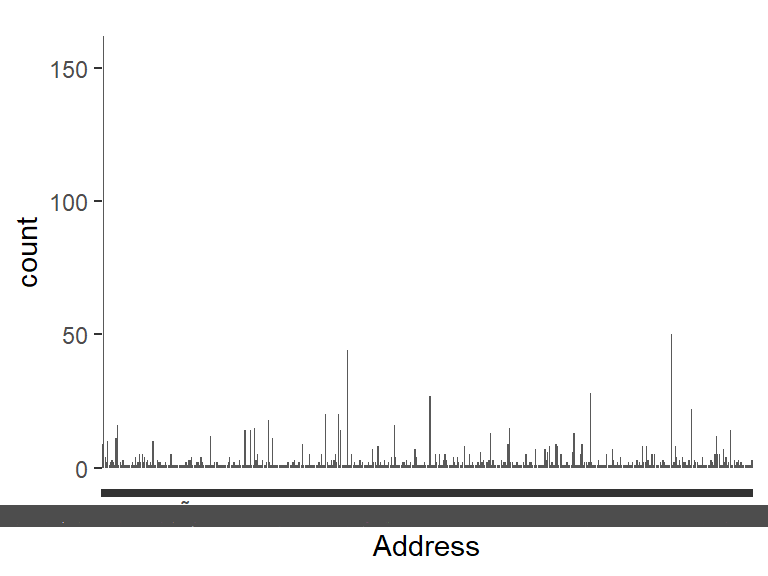

- Note that the following levels have at most five observations: "[‘107’, " St James’s Road", ’ Broad Green’, ’ London Borough of Croydon’, ’ London’, ’ Greater London’, ’ England’, ’ CR0 2GQ’, ’ United Kingdom’]", "[‘11’, ’ Albemarle Road’, ’ Belvedere Trading Estate’, ’ North Town’, ’ Taunton’, ’ Somerset West and Taunton’, ’ Somerset’, ’ South West England’, ’ England’, ’ TA1 1BB’, ’ United Kingdom’]", "[‘15’, " St. David’s Road", ’ Thornbury’, ’ South Gloucestershire’, ’ South West England’, ’ England’, ’ BS35 2JF’, ’ United Kingdom’]", "[‘17’, " Monkham’s Avenue", ’ Woodford’, ’ London Borough of Redbridge’, ’ London’, ’ Greater London’, ’ England’, ’ IG8 0HF’, ’ United Kingdom’]", "[‘19’, ’ Covanburn Avenue’, ’ Barncluith’, ’ Silvertonhill’, ’ Hamilton’, ’ South Lanarkshire’, ’ Scotland’, ’ ML3 7PX’, ’ United Kingdom’]", "[‘19’, ’ Innovation Way’, ’ Beechdale’, ’ Bloxwich’, ’ Walsall’, ’ West Midlands Combined Authority’, ’ West Midlands’, ’ England’, ’ WS2’, ’ United Kingdom’]", "[‘1st Fairford Scout Troop’, ’ Totterdown Lane’, ’ Fairford’, ’ Cotswold’, ’ Gloucestershire’, ’ South West England’, ’ England’, ’ GL7 4’, ’ United Kingdom’]", "[‘28’, ’ M62’, ’ Bruntcliffe’, ’ Morley’, ’ Woodkirk’, ’ Leeds’, ’ West Yorkshire’, ’ Yorkshire and the Humber’, ’ England’, ’ WF3 1JG’, ’ United Kingdom’]", "[‘35a - 35b’, ’ Old Hill Crescent’, ’ Christchurch’, ’ Caerleon’, ’ Newport’, ’ Gwent’, ’ Cymru / Wales’, ’ NP18 1JL’, ’ United Kingdom’]", "[‘36’, ’ Church Square’, ’ Rye’, ’ Rother’, ’ East Sussex’, ’ South East’, ’ England’, ’ TN31 7HE’, ’ United Kingdom’]" (419 additional values omitted).

## plant_in_city

| Feature | Result |
| --- | --- |
| Variable type | character |
| Number of missing obs. | 0 (0 %) |
| Number of unique values | 2 |
| Mode | “No” |

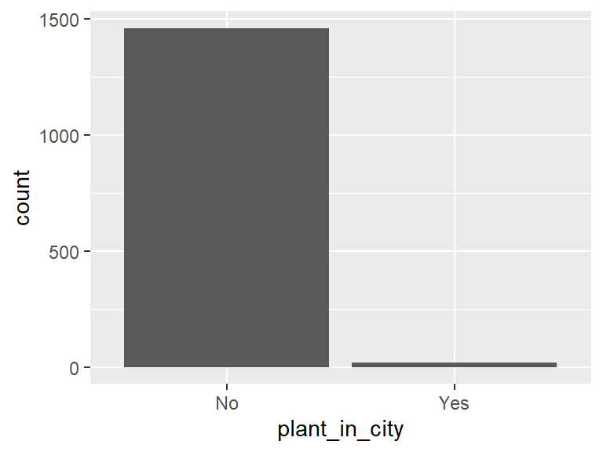

## plant_name

| Feature | Result |
| --- | --- |
| Variable type | character |
| Number of missing obs. | 0 (0 %) |
| Number of unique values | 10 |
| Mode | “None” |

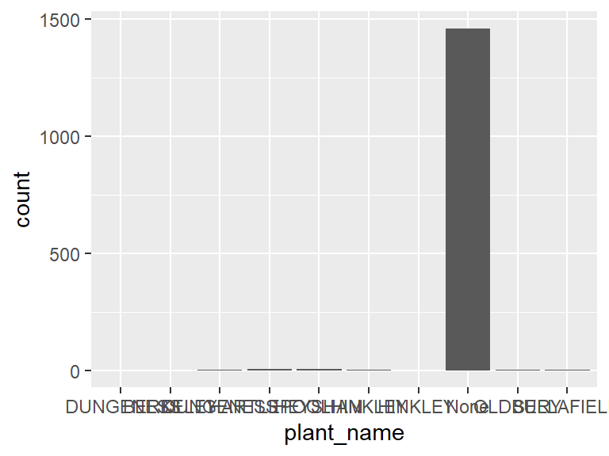

- The following values appear with prefixed or suffixed white space: " DUNGENESS", "HINKLEY ".
- Note that the following levels have at most five observations: " DUNGENESS", "BERKELEY", "DUNGENESS", "HARTLEPOOL", "HEYSHAM", "HINKLEY", "HINKLEY ", "OLDBURY", "SELLAFIELD".

## plant_latitude

| Feature | Result |
| --- | --- |
| Variable type | character |
| Number of missing obs. | 0 (0 %) |
| Number of unique values | 8 |
| Mode | “None” |

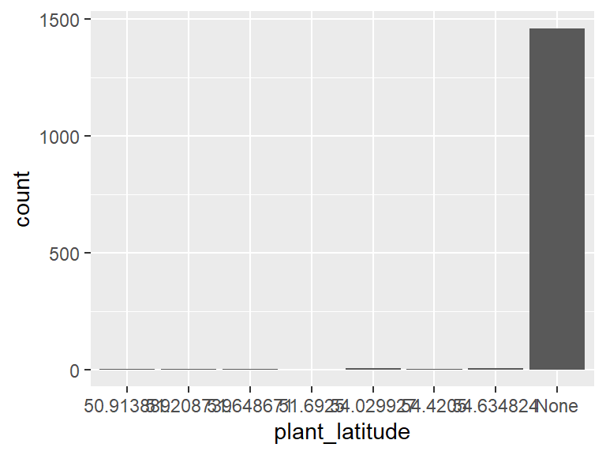

- Note that the following levels have at most five observations: "50.913889", "51.208739", "51.648671", "51.6925", "54.029927", "54.4205", "54.634824".

## plant_longitude

| Feature | Result |
| --- | --- |
| Variable type | character |
| Number of missing obs. | 0 (0 %) |
| Number of unique values | 8 |
| Mode | “None” |

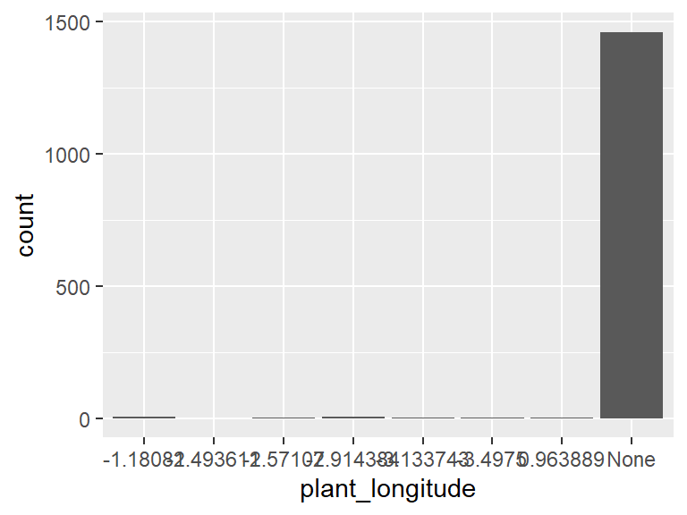

- Note that the following levels have at most five observations: "-1.18081", "-2.493611", "-2.57107", "-2.914384", "-3.133743", "-3.4975", "0.963889".

Report generation information:

- Created by: Could not determine from system (username: Unknown)
- Report creation time: Fri Dec 11 2020 17:05:34
- Report was run from directory: `C:/Users/brend/Dropbox/MaestriaC.D/1. Primer Semestre/2. Ingenieria de Caract/Trabajo final`
- dataMaid v1.4.0 [Pkg: 2019-12-10 from CRAN (R 4.0.2)]
- R version 4.0.3 (2020-10-10).
- Platform: x86_64-w64-mingw32/x64 (64-bit)(Windows 10 x64 (build 18363)).
- Function call: `makeDataReport(data = data1, render = FALSE, file = "codebook.Rmd", replace = TRUE, codebook = TRUE, reportTitle = "UFO sightings and Nuclear Plants in the UK")`